# Lab9

jche827

10/10/2021

```r
library(tree)
library(randomForest)
library(gbm)
```

# The Data Set

The data source for this lab is from UCI Machine Learning Repository. We using the QSAR biodegradation data set. The data set has 41 predictors (molecular descriptors) and one response variable class, which has two levels: RB (ready biodegradable) and NRB (not ready biodegradable).

```r
biodeg = read.csv("biodeg.csv", stringsAsFactors=TRUE)
head(biodeg)
```

```
##   SpMaxL   JDze nHM F01NN F04CN NssssC nCb    C nCp nO F03CN  SdssC HyWiBm
## 1  3.919 2.6909   0     0     0      0   0 31.4   2  0     0  0.000  3.106
## 2  4.170 2.1144   0     0     0      0   0 30.8   1  1     0  0.000  2.461
## 3  3.932 3.2512   0     0     0      0   0 26.7   2  4     0  0.000  3.279
## 4  3.000 2.7098   0     0     0      0   0 20.0   0  2     0  0.000  2.100
## 5  4.236 3.3944   0     0     0      0   0 29.4   2  4     0 -0.271  3.449
## 6  4.236 3.4286   0     0     0      0   0 28.6   2  4     0 -0.275  3.313
##     LOC  SM6L F03CO    Me    Mi nNN nArNO2 nCRX3 SpPosABp nCIR B01CBr B03CCl
## 1 2.550 9.002     0 0.960 1.142   0      0     0    1.201    0      0      0
## 2 1.393 8.723     1 0.989 1.144   0      0     0    1.104    1      0      0
## 3 2.585 9.110     0 1.009 1.152   0      0     0    1.092    0      0      0
## 4 0.918 6.594     0 1.108 1.167   0      0     0    1.024    0      0      0
## 5 2.753 9.528     2 1.004 1.147   0      0     0    1.137    0      0      0
## 6 2.522 9.383     1 1.014 1.149   0      0     0    1.119    0      0      0
##   N073 SpMaxA Psii1d B04CBr    SdO  TI2L nCrt C026 F02CN nHDon SpMaxBm PsiiA nN
## 1    0  1.932  0.011      0  0.000 4.489    0    0     0     0   2.949 1.591  0
## 2    0  2.214 -0.204      0  0.000 1.542    0    0     0     0   3.315 1.967  0
## 3    0  1.942 -0.008      0  0.000 4.891    0    0     0     1   3.076 2.417  0
## 4    0  1.414  1.073      0  8.361 1.333    0    0     0     1   3.046 5.000  0
## 5    0  1.985 -0.002      0 10.348 5.588    0    0     0     0   3.351 2.405  0
## 6    0  1.980 -0.008      0 10.276 4.746    0    0     0     0   3.351 2.556  0
##   SM6Bm nArCOOR nX class
## 1 7.253       0  0    RB
## 2 7.257       0  0    RB
## 3 7.601       0  0    RB
## 4 6.690       0  0    RB
## 5 8.003       0  0    RB
## 6 7.904       0  0    RB
```

# Training and Test Data

## 1. Randomly divide the data set into two halves, and save them in two data frames named train and test

```r
set.seed(123)
smp_size <- floor(0.5 * nrow(biodeg))
train_ind <- sample(seq_len(nrow(biodeg)), size = smp_size)
train <- biodeg[train_ind, ]
test <- biodeg[-train_ind, ]

head(train)
```

```
##     SpMaxL   JDze nHM F01NN F04CN NssssC nCb    C nCp nO F03CN SdssC HyWiBm
## 415  4.958 3.1448   0     0     0      0   3 40.0   3  1     0 0.000  3.272
## 463  4.732 2.1649   0     0     2      0   4 44.8   0  0     4 0.000  3.617
## 179  4.983 4.2631   0     0     0      0   0 23.1   2  6     0 0.000  3.342
## 526  5.054 2.3939   2     1     8      0   6 42.9   0  2    16 0.000  4.393
## 195  4.650 4.0313   0     0     1      0   0 31.3   3  2     0 0.159  3.390
## 938  4.770 3.0499   1     0     0      0   2 47.4   1  0     0 1.066  3.375
##       LOC   SM6L F03CO    Me    Mi nNN nArNO2 nCRX3 SpPosABp nCIR B01CBr B03CCl
## 415 1.160 10.099     3 0.981 1.125   0      0     0    1.268    1      0      0
## 463 0.648 10.300     0 0.983 1.120   0      0     0    1.293    2      0      0
## 179 1.792 10.074     8 1.044 1.160   0      0     0    1.011    0      0      0
## 526 1.709 10.966     4 1.032 1.128   0      1     0    1.289    2      0      1
## 195 2.134  9.916     5 0.991 1.145   0      0     0    1.184    0      0      0
## 938 1.185  9.882     0 0.986 1.106   0      0     0    1.348    1      0      1
##     N073 SpMaxA Psii1d B04CBr    SdO  TI2L nCrt C026 F02CN nHDon SpMaxBm PsiiA
## 415    0  2.303 -0.007      0  0.000 1.602    0    1     0     1   3.731 2.212
## 463    0  2.275  0.000      0  0.000 3.095    0    2     4     4   3.694 2.144
## 179    0  2.247 -0.008      0  0.000 2.666    0    0     0     6   3.397 3.694
## 526    0  2.374  0.000      0 21.618 5.285    0    6    14     0   4.090 2.758
## 195    0  2.122  0.004      0 10.961 3.936    0    0     3     0   3.527 2.372
## 938    0  2.236  0.013      0  0.000 1.740    0    1     0     0   3.881 2.211
##     nN SM6Bm nArCOOR nX class
## 415  0 8.236       0  0   NRB
## 463  2 8.636       0  0   NRB
## 179  0 7.880       0  0    RB
## 526  6 9.674       0  2   NRB
## 195  1 8.131       0  0    RB
## 938  0 8.620       0  1   NRB
```

```r
head(test)
```

```
##   SpMaxL   JDze nHM F01NN F04CN NssssC nCb    C nCp nO F03CN SdssC HyWiBm   LOC
## 1  3.919 2.6909   0     0     0      0   0 31.4   2  0     0     0  3.106 2.550
## 2  4.170 2.1144   0     0     0      0   0 30.8   1  1     0     0  2.461 1.393
## 3  3.932 3.2512   0     0     0      0   0 26.7   2  4     0     0  3.279 2.585
## 4  3.000 2.7098   0     0     0      0   0 20.0   0  2     0     0  2.100 0.918
## 7  5.000 5.0476   1     0     0      0   0 11.1   0  3     0     0  2.872 0.722
## 9  4.596 3.0777   0     0     0      0   2 44.4   2  0     0     0  2.970 0.875
##    SM6L F03CO    Me    Mi nNN nArNO2 nCRX3 SpPosABp nCIR B01CBr B03CCl N073
## 1 9.002     0 0.960 1.142   0      0     0    1.201    0      0      0    0
## 2 8.723     1 0.989 1.144   0      0     0    1.104    1      0      0    0
## 3 9.110     0 1.009 1.152   0      0     0    1.092    0      0      0    0
## 4 6.594     0 1.108 1.167   0      0     0    1.024    0      0      0    0
## 7 9.657     0 1.092 1.153   0      0     0    1.125    0      0      0    0
## 9 9.540     0 0.968 1.115   0      0     0    1.328    1      0      0    0
##   SpMaxA Psii1d B04CBr    SdO  TI2L nCrt C026 F02CN nHDon SpMaxBm PsiiA nN
## 1  1.932  0.011      0  0.000 4.489    0    0     0     0   2.949 1.591  0
## 2  2.214 -0.204      0  0.000 1.542    0    0     0     0   3.315 1.967  0
## 3  1.942 -0.008      0  0.000 4.891    0    0     0     1   3.076 2.417  0
## 4  1.414  1.073      0  8.361 1.333    0    0     0     1   3.046 5.000  0
## 7  2.000  0.446      0 18.375 0.800    0    0     0     1   4.712 4.583  0
## 9  2.175  0.041      0  0.000 1.069    0    0     0     0   3.626 1.917  0
##   SM6Bm nArCOOR nX class
## 1 7.253       0  0    RB
## 2 7.257       0  0    RB
## 3 7.601       0  0    RB
## 4 6.690       0  0    RB
## 7 9.303       0  0    RB
## 9 7.939       0  0    RB
```

```r
dim(biodeg)
```

```
## [1] 1055   42
```

```r
dim(test)
```

```
## [1] 528  42
```

```r
dim(train)
```

```
## [1] 527  42
```

# Classification trees

## 2. Fit an unpruned classification tree to the training data. Plot it (as pretty as you can)

```r
(r = tree(class ~ ., data=train))
```

```
## node), split, n, deviance, yval, (yprob)
##       * denotes terminal node
##
##  1) root 527 675.400 NRB ( 0.66034 0.33966 )
##    2) SpMaxBm < 3.6725 229 307.700 RB ( 0.39738 0.60262 )
##      4) SdO < 4.5 118 156.900 NRB ( 0.61864 0.38136 )
##        8) F02CN < 2.5 96 132.700 NRB ( 0.53125 0.46875 )
##         16) SpMaxL < 4.624 68  91.360 RB ( 0.39706 0.60294 )
##           32) nHDon < 0.5 34  45.230 NRB ( 0.61765 0.38235 )
##             64) HyWiBm < 2.558 5   0.000 RB ( 0.00000 1.00000 ) *
##             65) HyWiBm > 2.558 29  34.160 NRB ( 0.72414 0.27586 ) *
##           33) nHDon > 0.5 34  31.690 RB ( 0.17647 0.82353 )
##             66) Mi < 1.1625 27   8.554 RB ( 0.03704 0.96296 ) *
##             67) Mi > 1.1625 7   8.376 NRB ( 0.71429 0.28571 ) *
##         17) SpMaxL > 4.624 28  22.970 NRB ( 0.85714 0.14286 ) *
##        9) F02CN > 2.5 22   0.000 NRB ( 1.00000 0.00000 ) *
##      5) SdO > 4.5 111  98.400 RB ( 0.16216 0.83784 )
##       10) SpMaxL < 5.1005 98  60.130 RB ( 0.09184 0.90816 )
##         20) nN < 0.5 76  10.650 RB ( 0.01316 0.98684 ) *
##         21) nN > 0.5 22  28.840 RB ( 0.36364 0.63636 ) *
##       11) SpMaxL > 5.1005 13  16.050 NRB ( 0.69231 0.30769 ) *
##    3) SpMaxBm > 3.6725 298 238.700 NRB ( 0.86242 0.13758 )
##      6) SdssC < -0.7405 46  63.770 NRB ( 0.50000 0.50000 )
##       12) SpMaxL < 5.154 30  34.790 RB ( 0.26667 0.73333 )
##         24) F04CN < 1.5 25  18.350 RB ( 0.12000 0.88000 )
##           48) LOC < 1.626 16   0.000 RB ( 0.00000 1.00000 ) *
##           49) LOC > 1.626 9  11.460 RB ( 0.33333 0.66667 ) *
##         25) F04CN > 1.5 5   0.000 NRB ( 1.00000 0.00000 ) *
##       13) SpMaxL > 5.154 16   7.481 NRB ( 0.93750 0.06250 ) *
##      7) SdssC > -0.7405 252 129.700 NRB ( 0.92857 0.07143 )
##       14) SM6Bm < 8.4885 43  50.920 NRB ( 0.72093 0.27907 )
##         28) Mi < 1.115 10  12.220 RB ( 0.30000 0.70000 ) *
##         29) Mi > 1.115 33  28.070 NRB ( 0.84848 0.15152 )
##           58) F03CO < 3.5 16   0.000 NRB ( 1.00000 0.00000 ) *
##           59) F03CO > 3.5 17  20.600 NRB ( 0.70588 0.29412 ) *
##       15) SM6Bm > 8.4885 209  54.430 NRB ( 0.97129 0.02871 )
##         30) F03CN < 0.5 114  47.010 NRB ( 0.94737 0.05263 ) *
##         31) F03CN > 0.5 95   0.000 NRB ( 1.00000 0.00000 ) *
```

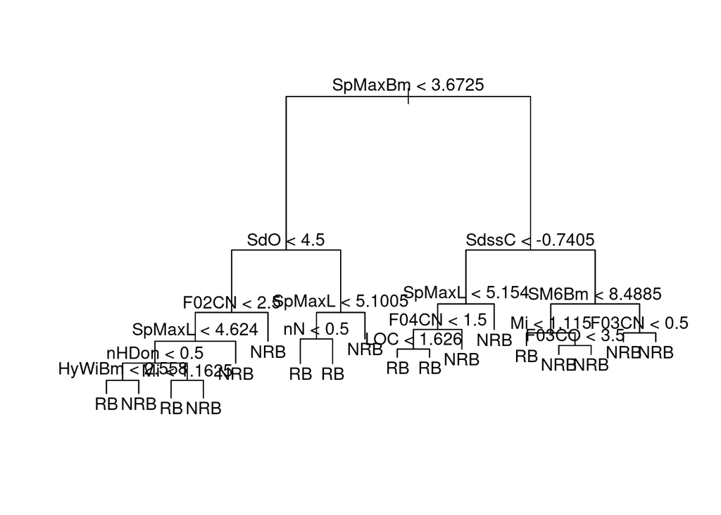

```r
plot(r)
text(r, pretty=0)
```

## 3. Compute the training and test errors

```r
yhat = predict(r, newdata=train)
head(yhat)
```

```
##           NRB         RB
## 415 1.0000000 0.00000000
## 463 1.0000000 0.00000000
## 179 0.8571429 0.14285714
## 526 1.0000000 0.00000000
## 195 0.3636364 0.63636364
## 938 0.9473684 0.05263158
```

```r
head(train$class)
```

```
## [1] NRB NRB RB  NRB RB  NRB
## Levels: NRB RB
```

```r
A = mean(train$class == ifelse(yhat>=0.5, "NRB", "RB"))
A
```

```
## [1] 0.5
```

```r
yhat = predict(r, newdata=test)
head(yhat)
```

```
##          NRB         RB
## 1 0.72413793 0.27586207
## 2 0.00000000 1.00000000
## 3 0.03703704 0.96296296
## 4 0.01315789 0.98684211
## 7 0.94736842 0.05263158
## 9 0.72413793 0.27586207
```

```r
head(test$class)
```

```
## [1] RB RB RB RB RB RB
## Levels: NRB RB
```

```r
A = mean(test$class == ifelse(yhat>=0.5, "NRB", "RB"))
A
```

```
## [1] 0.5
```

## 4. Consider pruning the tree using cross-validation with deviance. Produce a pruned tree based by selecting a cost-complexity parameter value, and plot it.

```r
(cv.r = cv.tree(r))    # Cross-validation, K = 10 by default (so we don't have to implement it)
```

```
## $size
##  [1] 18 17 16 15 14 13 11 10  9  8  7  6  5  4  3  2  1
##
## $dev
##  [1] 657.6842 606.8338 595.0664 595.0664 502.1567 512.9407 521.4207 512.5431
##  [9] 514.2190 514.7169 526.3449 523.8271 514.0768 507.9419 535.8156 554.9406
## [17] 677.6159
##
## $k
##  [1]       -Inf   6.888995   7.421189   7.474552  10.629290  11.071739
##  [7]  14.600556  16.448661  18.377553  20.636861  21.493297  22.224220
## [13]  24.165855  24.337375  45.271565  52.472546 128.936403
##
## $method
## [1] "deviance"
##
## attr(,"class")
## [1] "prune"         "tree.sequence"
```

```r
(j.min = which.min(cv.r$dev))          # smallest CV deviance
```

```
## [1] 5
```

```r
(size = cv.r$size[j.min])
```

```
## [1] 14
```

```r
(r2 = prune.tree(r, best=size))        # tree pruning, based on the best size
```

```
## node), split, n, deviance, yval, (yprob)
##       * denotes terminal node
##
##  1) root 527 675.400 NRB ( 0.66034 0.33966 )
##    2) SpMaxBm < 3.6725 229 307.700 RB ( 0.39738 0.60262 )
##      4) SdO < 4.5 118 156.900 NRB ( 0.61864 0.38136 )
##        8) F02CN < 2.5 96 132.700 NRB ( 0.53125 0.46875 )
##         16) SpMaxL < 4.624 68  91.360 RB ( 0.39706 0.60294 )
##           32) nHDon < 0.5 34  45.230 NRB ( 0.61765 0.38235 )
##             64) HyWiBm < 2.558 5   0.000 RB ( 0.00000 1.00000 ) *
##             65) HyWiBm > 2.558 29  34.160 NRB ( 0.72414 0.27586 ) *
##           33) nHDon > 0.5 34  31.690 RB ( 0.17647 0.82353 )
##             66) Mi < 1.1625 27   8.554 RB ( 0.03704 0.96296 ) *
##             67) Mi > 1.1625 7   8.376 NRB ( 0.71429 0.28571 ) *
##         17) SpMaxL > 4.624 28  22.970 NRB ( 0.85714 0.14286 ) *
##        9) F02CN > 2.5 22   0.000 NRB ( 1.00000 0.00000 ) *
##      5) SdO > 4.5 111  98.400 RB ( 0.16216 0.83784 )
##       10) SpMaxL < 5.1005 98  60.130 RB ( 0.09184 0.90816 )
##         20) nN < 0.5 76  10.650 RB ( 0.01316 0.98684 ) *
##         21) nN > 0.5 22  28.840 RB ( 0.36364 0.63636 ) *
##       11) SpMaxL > 5.1005 13  16.050 NRB ( 0.69231 0.30769 ) *
##    3) SpMaxBm > 3.6725 298 238.700 NRB ( 0.86242 0.13758 )
##      6) SdssC < -0.7405 46  63.770 NRB ( 0.50000 0.50000 )
##       12) SpMaxL < 5.154 30  34.790 RB ( 0.26667 0.73333 )
##         24) F04CN < 1.5 25  18.350 RB ( 0.12000 0.88000 ) *
##         25) F04CN > 1.5 5   0.000 NRB ( 1.00000 0.00000 ) *
##       13) SpMaxL > 5.154 16   7.481 NRB ( 0.93750 0.06250 ) *
##      7) SdssC > -0.7405 252 129.700 NRB ( 0.92857 0.07143 )
##       14) SM6Bm < 8.4885 43  50.920 NRB ( 0.72093 0.27907 ) *
##       15) SM6Bm > 8.4885 209  54.430 NRB ( 0.97129 0.02871 ) *
```

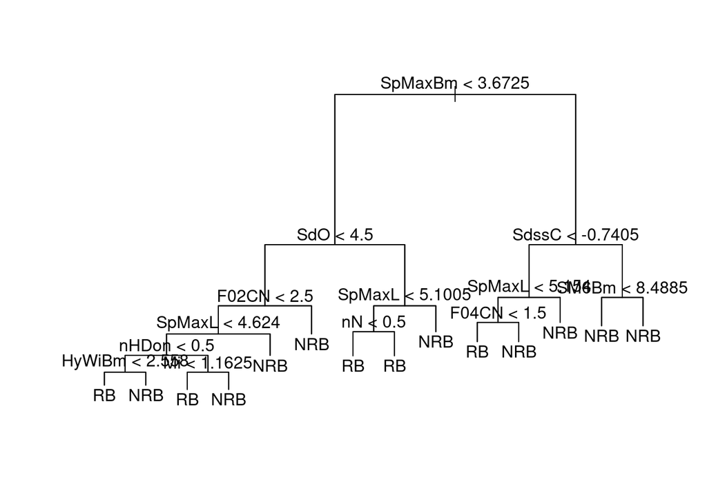

```r
plot(r2)
text(r2, pretty=0)
```

### Compute the training and test errors for this pruned tree

```r
yhat = predict(r2, newdata=train)
head(yhat)
```

```
##           NRB         RB
## 415 0.7209302 0.27906977
## 463 0.9712919 0.02870813
## 179 0.8571429 0.14285714
## 526 0.9712919 0.02870813
## 195 0.3636364 0.63636364
## 938 0.9712919 0.02870813
```

```r
head(train$class)
```

```
## [1] NRB NRB RB  NRB RB  NRB
## Levels: NRB RB
```

```r
A = mean(train$class == ifelse(yhat>=0.5, "NRB", "RB"))
A
```

```
## [1] 0.5
```

```r
yhat = predict(r2, newdata=test)
head(yhat)
```

```
##          NRB         RB
## 1 0.72413793 0.27586207
## 2 0.00000000 1.00000000
## 3 0.03703704 0.96296296
## 4 0.01315789 0.98684211
## 7 0.97129187 0.02870813
## 9 0.72413793 0.27586207
```

```r
head(test$class)
```

```
## [1] RB RB RB RB RB RB
## Levels: NRB RB
```

```r
A = mean(test$class == ifelse(yhat>=0.5, "NRB", "RB"))
A
```

```
## [1] 0.5
```

## 5. Consider pruning the tree using cross-validation with misclassification rates. Produce a pruned tree by selecting a tree size, and plot it

```r
set.seed(769)
(cv.r = cv.tree(r, method="misclass"))    # use misclassification rate
```

```
## $size
## [1] 18 14 12 11  8  6  3  2  1
##
## $dev
## [1]  95  94  96 105 100 121 115 137 181
##
## $k
## [1]      -Inf  0.000000  2.000000  3.000000  5.000000  7.000000  7.333333
## [8] 28.000000 47.000000
##
## $method
## [1] "misclass"
##
## attr(,"class")
## [1] "prune"         "tree.sequence"
```

```r
# $dev are the numbers of misclassified observations
(j.min = max(which(cv.r$dev == min(cv.r$dev))))     # if more than one, usually choose the simplest model
```

```
## [1] 2
```

```r
(k = cv.r$k[j.min])             # cost-complexity parameter
```

```
## [1] 0
```

```r
(r2 = prune.tree(r, k=k, method="misclass"))       # pruned tree
```

```
## node), split, n, deviance, yval, (yprob)
##       * denotes terminal node
##
##  1) root 527 675.400 NRB ( 0.66034 0.33966 )
##    2) SpMaxBm < 3.6725 229 307.700 RB ( 0.39738 0.60262 )
##      4) SdO < 4.5 118 156.900 NRB ( 0.61864 0.38136 )
##        8) F02CN < 2.5 96 132.700 NRB ( 0.53125 0.46875 )
##         16) SpMaxL < 4.624 68  91.360 RB ( 0.39706 0.60294 )
##           32) nHDon < 0.5 34  45.230 NRB ( 0.61765 0.38235 )
##             64) HyWiBm < 2.558 5   0.000 RB ( 0.00000 1.00000 ) *
##             65) HyWiBm > 2.558 29  34.160 NRB ( 0.72414 0.27586 ) *
##           33) nHDon > 0.5 34  31.690 RB ( 0.17647 0.82353 )
##             66) Mi < 1.1625 27   8.554 RB ( 0.03704 0.96296 ) *
##             67) Mi > 1.1625 7   8.376 NRB ( 0.71429 0.28571 ) *
##         17) SpMaxL > 4.624 28  22.970 NRB ( 0.85714 0.14286 ) *
##        9) F02CN > 2.5 22   0.000 NRB ( 1.00000 0.00000 ) *
##      5) SdO > 4.5 111  98.400 RB ( 0.16216 0.83784 )
##       10) SpMaxL < 5.1005 98  60.130 RB ( 0.09184 0.90816 ) *
##       11) SpMaxL > 5.1005 13  16.050 NRB ( 0.69231 0.30769 ) *
##    3) SpMaxBm > 3.6725 298 238.700 NRB ( 0.86242 0.13758 )
##      6) SdssC < -0.7405 46  63.770 NRB ( 0.50000 0.50000 )
##       12) SpMaxL < 5.154 30  34.790 RB ( 0.26667 0.73333 )
##         24) F04CN < 1.5 25  18.350 RB ( 0.12000 0.88000 ) *
##         25) F04CN > 1.5 5   0.000 NRB ( 1.00000 0.00000 ) *
##       13) SpMaxL > 5.154 16   7.481 NRB ( 0.93750 0.06250 ) *
##      7) SdssC > -0.7405 252 129.700 NRB ( 0.92857 0.07143 )
##       14) SM6Bm < 8.4885 43  50.920 NRB ( 0.72093 0.27907 )
##         28) Mi < 1.115 10  12.220 RB ( 0.30000 0.70000 ) *
##         29) Mi > 1.115 33  28.070 NRB ( 0.84848 0.15152 ) *
##       15) SM6Bm > 8.4885 209  54.430 NRB ( 0.97129 0.02871 ) *
```

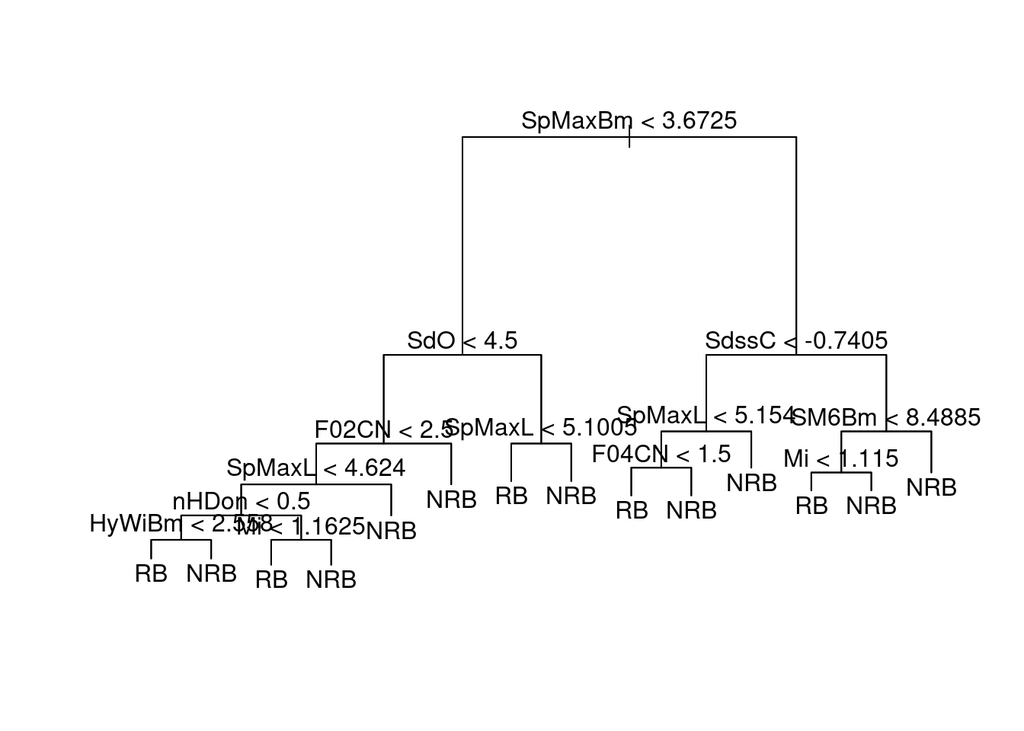

```r
plot(r2)
text(r2, pretty=0)
```

### Compute the training and test errors for this pruned tree

```r
yhat = predict(r2, newdata=train)
head(yhat)
```

```
##            NRB         RB
## 415 0.84848485 0.15151515
## 463 0.97129187 0.02870813
## 179 0.85714286 0.14285714
## 526 0.97129187 0.02870813
## 195 0.09183673 0.90816327
## 938 0.97129187 0.02870813
```

```r
head(train$class)
```

```
## [1] NRB NRB RB  NRB RB  NRB
## Levels: NRB RB
```

```r
A = mean(train$class == ifelse(yhat>=0.5, "NRB", "RB"))
A
```

```
## [1] 0.5
```

```r
yhat = predict(r2, newdata=test)
head(yhat)
```

```
##          NRB         RB
## 1 0.72413793 0.27586207
## 2 0.00000000 1.00000000
## 3 0.03703704 0.96296296
## 4 0.09183673 0.90816327
## 7 0.97129187 0.02870813
## 9 0.72413793 0.27586207
```

```r
head(test$class)
```

```
## [1] RB RB RB RB RB RB
## Levels: NRB RB
```

```r
A = mean(test$class == ifelse(yhat>=0.5, "NRB", "RB"))
A
```

```
## [1] 0.5
```

### Do you think the pruning helps?

Based off my results, it does not help. However my results may be incorrect, so it should be considered that they may work if the results are accurate. I didn’t have much time for this lab.

# Bagging

```r
library(randomForest)

set.seed(769)
(r = randomForest(class ~ ., data=biodeg, mtry=500, importance=TRUE))
```

```
##
## Call:
##  randomForest(formula = class ~ ., data = biodeg, mtry = 500,      importance = TRUE)
##                Type of random forest: classification
##                      Number of trees: 500
## No. of variables tried at each split: 41
##
##         OOB estimate of  error rate: 12.61%
## Confusion matrix:
##     NRB  RB class.error
## NRB 647  52  0.07439199
## RB   81 275  0.22752809
```

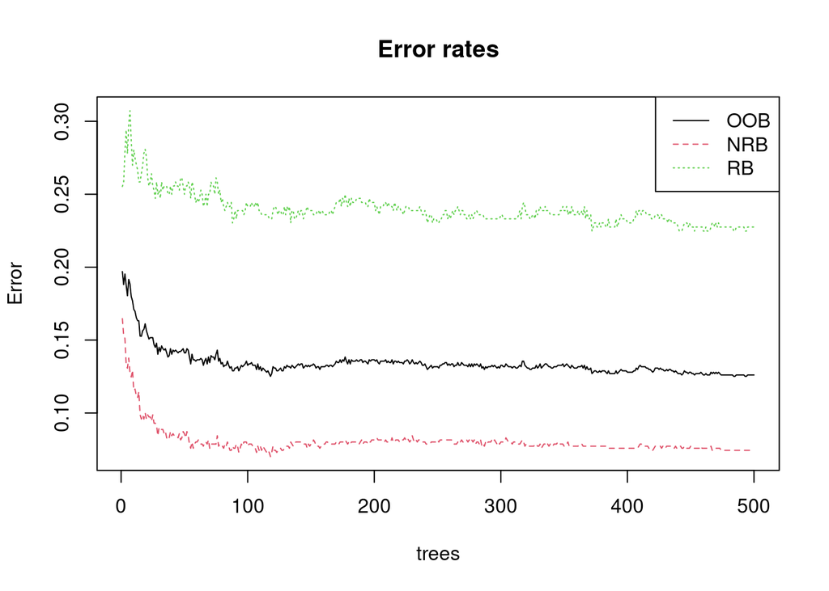

```r
plot(r, main="Error rates")      # error rates
legend("topright", leg=colnames(r$err.rate), lty=1:3, col=1:3)
```

```r
round(importance(r), 2)   # show importance of variables - higher values mean more important
```

```
##            NRB    RB MeanDecreaseAccuracy MeanDecreaseGini
## SpMaxL   13.39 29.28                33.23            31.34
## JDze     12.93 10.62                17.18            13.92
## nHM      -0.73 13.11                13.62             2.25
## F01NN     3.70  1.85                 3.72             0.29
## F04CN     3.36 11.82                12.65             4.18
## NssssC    8.22 10.13                10.81             5.56
## nCb       6.58  3.80                 8.60             1.86
## C         8.36  7.08                12.13            10.32
## nCp       8.55 18.71                20.09             8.00
## nO       13.30  8.79                15.71             8.43
## F03CN     5.72 10.74                12.14             4.74
## SdssC    16.92 21.10                26.01            22.72
## HyWiBm   18.26  7.81                19.76            11.73
## LOC      15.72 14.48                22.44            13.82
## SM6L      9.96  8.84                13.73             8.97
## F03CO    15.96 13.02                19.32            12.26
## Me       12.78  7.91                16.43             9.60
## Mi       12.86 12.00                19.07            15.92
## nNN       4.07  2.25                 4.30             0.34
## nArNO2    2.98  0.25                 2.89             0.21
## nCRX3     1.00  1.00                 1.42             0.02
## SpPosABp 14.58 15.32                20.47            16.62
## nCIR      2.73  5.09                 6.61             1.40
## B01CBr    3.85 -1.00                 3.75             0.28
## B03CCl    2.27  7.23                 7.43             0.93
## N073      0.92 -2.15                 0.15             0.22
## SpMaxA   12.07  9.23                16.06            11.02
## Psii1d   12.03 -1.70                11.29             7.90
## B04CBr    2.66 -1.00                 2.48             0.32
## SdO      11.74 11.14                14.41            11.25
## TI2L     11.25  8.47                14.87             9.26
## nCrt      7.32  8.36                11.44             2.82
## C026      4.54  4.52                 6.60             1.54
## F02CN    10.21 25.19                25.95            19.82
## nHDon     4.01  4.93                 6.58             3.78
## SpMaxBm  41.35 37.71                72.28           131.88
## PsiiA    18.54 10.64                21.79            17.20
## nN       10.52 20.45                21.65            12.42
## SM6Bm    27.47 10.85                30.53            21.74
## nArCOOR  12.08 20.30                21.61            12.15
## nX        1.51 13.60                13.87             2.33
```

```r
yhat = predict(r, biodeg)
table(biodeg$class, yhat)    # confusion table
```

```
##      yhat
##       NRB  RB
##   NRB 699   0
##   RB    0 356
```

```r
mean(biodeg$class == yhat)   # classification accuracy -- resubstitution
```

```
## [1] 1
```

### What are the three most important variables, in terms of decreasing the Gini index, according to Bagging?

The highest mean decreases are from SpMaxBm, SpMaxL and SdssC, in descending order.

# Random Forests

```r
set.seed(769)
(r = randomForest(class ~ ., data=biodeg, mtry=500, importance=TRUE))
```

```
##
## Call:
##  randomForest(formula = class ~ ., data = biodeg, mtry = 500,      importance = TRUE)
##                Type of random forest: classification
##                      Number of trees: 500
## No. of variables tried at each split: 41
##
##         OOB estimate of  error rate: 12.61%
## Confusion matrix:
##     NRB  RB class.error
## NRB 647  52  0.07439199
## RB   81 275  0.22752809
```

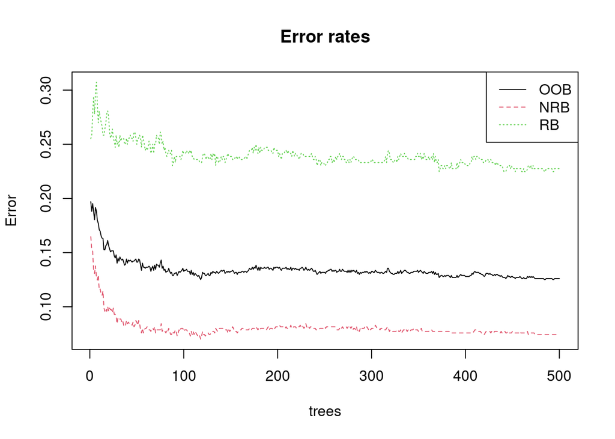

```r
plot(r, main="Error rates")      # error rates
legend("topright", leg=colnames(r$err.rate), lty=1:3, col=1:3)
```

```r
round(importance(r), 2)
```

```
##            NRB    RB MeanDecreaseAccuracy MeanDecreaseGini
## SpMaxL   13.39 29.28                33.23            31.34
## JDze     12.93 10.62                17.18            13.92
## nHM      -0.73 13.11                13.62             2.25
## F01NN     3.70  1.85                 3.72             0.29
## F04CN     3.36 11.82                12.65             4.18
## NssssC    8.22 10.13                10.81             5.56
## nCb       6.58  3.80                 8.60             1.86
## C         8.36  7.08                12.13            10.32
## nCp       8.55 18.71                20.09             8.00
## nO       13.30  8.79                15.71             8.43
## F03CN     5.72 10.74                12.14             4.74
## SdssC    16.92 21.10                26.01            22.72
## HyWiBm   18.26  7.81                19.76            11.73
## LOC      15.72 14.48                22.44            13.82
## SM6L      9.96  8.84                13.73             8.97
## F03CO    15.96 13.02                19.32            12.26
## Me       12.78  7.91                16.43             9.60
## Mi       12.86 12.00                19.07            15.92
## nNN       4.07  2.25                 4.30             0.34
## nArNO2    2.98  0.25                 2.89             0.21
## nCRX3     1.00  1.00                 1.42             0.02
## SpPosABp 14.58 15.32                20.47            16.62
## nCIR      2.73  5.09                 6.61             1.40
## B01CBr    3.85 -1.00                 3.75             0.28
## B03CCl    2.27  7.23                 7.43             0.93
## N073      0.92 -2.15                 0.15             0.22
## SpMaxA   12.07  9.23                16.06            11.02
## Psii1d   12.03 -1.70                11.29             7.90
## B04CBr    2.66 -1.00                 2.48             0.32
## SdO      11.74 11.14                14.41            11.25
## TI2L     11.25  8.47                14.87             9.26
## nCrt      7.32  8.36                11.44             2.82
## C026      4.54  4.52                 6.60             1.54
## F02CN    10.21 25.19                25.95            19.82
## nHDon     4.01  4.93                 6.58             3.78
## SpMaxBm  41.35 37.71                72.28           131.88
## PsiiA    18.54 10.64                21.79            17.20
## nN       10.52 20.45                21.65            12.42
## SM6Bm    27.47 10.85                30.53            21.74
## nArCOOR  12.08 20.30                21.61            12.15
## nX        1.51 13.60                13.87             2.33
```

```r
yhat = predict(r, biodeg)
table(biodeg$class, yhat)    # confusion table
```

```
##      yhat
##       NRB  RB
##   NRB 699   0
##   RB    0 356
```

```r
mean(biodeg$class == yhat)   # classification accuracy -- resubstitution
```

```
## [1] 1
```

### What are the three most important variables, in terms of accuracy, according to Random Forest?

SpMaxBm, SpMaxL and SM6Bm, in descending order.

# Boosting

## 10. Produce a Boosting model, with 500 trees constructed.

```r
library(gbm)     # Gradient Boosting Machine

set.seed(769)
# use distribution="bernoulli" for a two-class classification problem
biodeg2 = cbind(biodeg, class2=as.integer(biodeg$class)-1)   # requires integer values
(r = gbm(class2 ~ . - class, data=biodeg2, distribution="bernoulli", n.trees=500, interaction.depth=3))
```

```
## gbm(formula = class2 ~ . - class, distribution = "bernoulli",
##     data = biodeg2, n.trees = 500, interaction.depth = 3)
## A gradient boosted model with bernoulli loss function.
## 500 iterations were performed.
## There were 41 predictors of which 34 had non-zero influence.
```

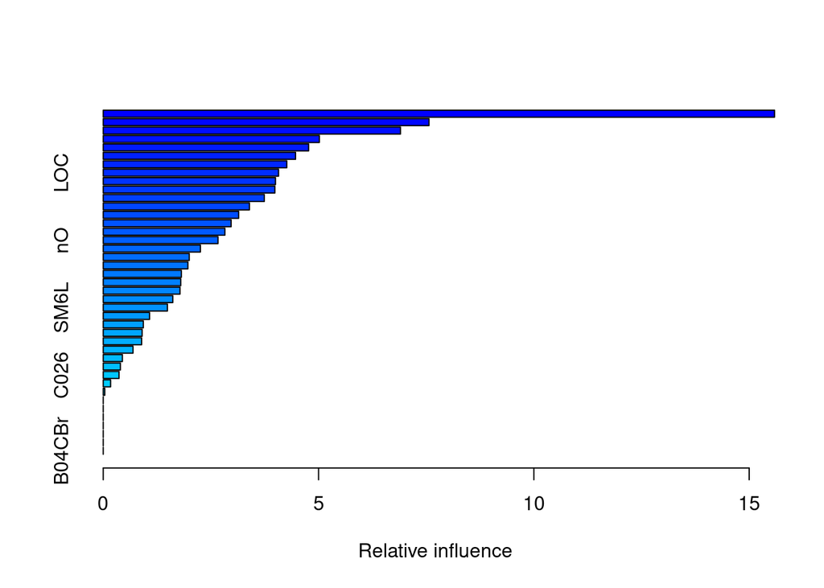

```
##               var     rel.inf
## SpMaxBm   SpMaxBm 15.58951425
## SpMaxL     SpMaxL  7.56479497
## SpPosABp SpPosABp  6.90294371
## SpMaxA     SpMaxA  5.01827551
## SdssC       SdssC  4.76953313
## HyWiBm     HyWiBm  4.46609865
## PsiiA       PsiiA  4.26197095
## LOC           LOC  4.07146048
## F02CN       F02CN  4.00011868
## JDze         JDze  3.98601363
## SM6Bm       SM6Bm  3.74032574
## TI2L         TI2L  3.39478194
## Mi             Mi  3.14492714
## C               C  2.96920429
## nN             nN  2.82485270
## nO             nO  2.66520784
## SdO           SdO  2.25659973
## nCp           nCp  1.99710458
## Me             Me  1.96589613
## nArCOOR   nArCOOR  1.81420701
## F03CO       F03CO  1.79980132
## F04CN       F04CN  1.78255507
## Psii1d     Psii1d  1.61485057
## SM6L         SM6L  1.49072454
## nHDon       nHDon  1.07508617
## nX             nX  0.93067519
## NssssC     NssssC  0.90266927
## nHM           nHM  0.89098413
## nCrt         nCrt  0.69157945
## F03CN       F03CN  0.44461097
## nCb           nCb  0.39854604
## C026         C026  0.36696731
## nCIR         nCIR  0.17125122
## nArNO2     nArNO2  0.03586766
## F01NN       F01NN  0.00000000
## nNN           nNN  0.00000000
## nCRX3       nCRX3  0.00000000
## B01CBr     B01CBr  0.00000000
## B03CCl     B03CCl  0.00000000
## N073         N073  0.00000000
## B04CBr     B04CBr  0.00000000
```

```r
summary(r)
```

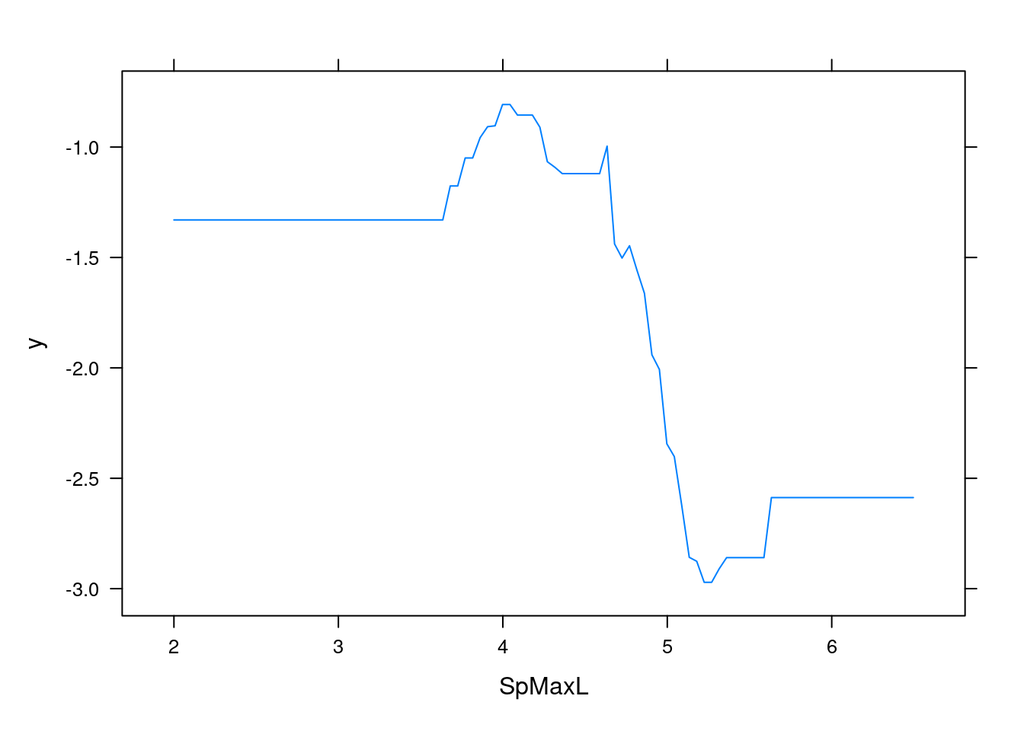

```r
plot(r)
```

```r
p = predict(r, biodeg, type="response")
```

```
## Using 500 trees...
```

```r
head(p)
```

```
## [1] 0.9773171 0.7443259 0.8105625 0.9830338 0.9899899 0.9462860
```

```r
yhat = (p > 0.5) + 1
table(biodeg$class, levels(biodeg$class)[yhat])    # confusion table
```

```
##
##       NRB  RB
##   NRB 698   1
##   RB    5 351
```

```r
mean(biodeg$class == yhat)                       # classification accuracy -- resubstitution
```

```
## [1] 0
```

### What are the three most important variables, according to Boosting?

SpMaxBm, SpMaxL, SpPosABp, based off the influence ranking.

# Summary

In this lab, I attempted a bit of tree classification. Plotting trees, and testing accuracy for test and train sets. Also bagging and boosting were used, and from these methods we see that they classify differen’t varibales to be more important. Both ensembles were used with 500 trees. Overall didn’t have much time at all for this lab, but still managed to grasp an understanding of the algorithms at a high level, but not a low level technical underderstanding.